# IMAP-PART 04 Quality Control of Microbiome Next Generation Sequencing Reads

Fostering Reproducible Microbiome data Analysis with Snakemake workflow

Teresia Mrema-Buza

IMAP-PART 04 [Latest GitHub-Repo](https://github.com/tmbuza/imap-read-quality-control/) Maintained by Teresia Mrema-Buza **Updated on 2023-04-11

# Getting started with read QC

## Snakemake workflow for read QC

[figure not shown]

A tentative snakemake workflow that defines **read quality control rules** in a DAG (directed acyclic graph) format. A detailed interactive snakemake report is available [here](https://complexdatainsights.com/imap/imap-read-quality-control/report.html). Use a wider screen to get a better interactive snakemake report.

## Some potential QC tools

- Seqkit
- Fastqc
- MultiQC
- BBDuk script
- Trimmomatic
- Kneaddata

## Some QC resources

- Adapter fasta files
- PhiX fasta file

## Tool dictionary (environment.yml)

```bash
name: readqc
channels:
    - bioconda
    - biobakery
dependencies:
    - seqkit =2.3.1
    - fastqc =0.12.1
    - multiqc =1.14
    - bbmap =39.01
    - trimmomatic =0.39
    - knead-data =0.12.0
```

```bash
conda activate base
mamba install -c bioconda -c conda-forge -n readqc -file environment.yml
```

## Read simple statistics

Assuming that the `seqkit` installation was successful, we can use it to get the simple statistics of the reads. Later we will use the `seqkit` output to prepare sample mapping files automatically.

- If the files are uncompressed, we can save space by compressing them.
- Let’s navigate to the folder containing the fastq files and compress them using `gzip` function.

```bash
gzip *.fastq
```

> From this point forward, we will assume that all the fastq files are in fastq.gz format.

```bash
#!/bin/bash

echo PROGRESS: Getting stats of the raw reads.

INPUTDIR="resources/reads"
SEQKIT="results/qc/seqkit1"
mkdir -p "${SEQKIT}"
seqkit stat "${INPUTDIR}"/*.fastq.gz >"${SEQKIT}"/seqkit_stats.txt
```

## Read Quality Control

- Assuming that most QC tools are ready, it is time to use them to do the following:
  - Check the quality of the reads using `fastqc`.
  - Create a summary report of quality metrics using `multiqc`.
  - Trim poor read at a user-specified cutoff using `bbduk.sh`.
  - Remove contaminants `bbduk.sh`.

### QC on raw reads

[figure not shown]

### QC after trimming poor reads

[figure not shown]

### QC after removing contaminated reads

[figure not shown]

### Processed read status

[figure not shown]

# Related work

| Repo | Description | Status |
| --- | --- | --- |
| [IMAP-GLIMPSE](https://github.com/datainsights/imap-project-overview/) | IMAP project overview | [In-progress](https://datainsights.github.io/imap-project-overview/) |
| [IMAP-PART 01](https://github.com/tmbuza/imap-software-requirements/) | Software requirement for microbiome data analysis with Snakemake workflows | [In-progress](https://tmbuza.github.io/imap-software-requirements/) |
| [IMAP-PART 02](https://github.com/tmbuza/imap-sample-metadata/) | Downloading and exploring microbiome sample metadata from SRA Database | [In-progress](https://tmbuza.github.io/imap-sample-metadata/) |
| [IMAP-PART 03](https://github.com/tmbuza/imap-download-sra-reads/) | Downloading and filtering microbiome sequencing data from SRA database | [In-progress](https://tmbuza.github.io/imap-download-sra-reads/) |
| [IMAP-PART 04](https://github.com/tmbuza/imap-read-quality-control/) | Quality Control of Microbiome Next Generation Sequencing Reads | [In-progress](https://tmbuza.github.io/imap-read-quality-control/) |
| [IMAP-PART 05](https://github.com/tmbuza/imap-bioinformatics-mothur/) | Microbial profiling using MOTHUR and Snakemake workflows | [In-progress](https://tmbuza.github.io/imap-bioinformatics-mothur/) |
| [IMAP-PART 06](https://github.com/tmbuza/imap-bioinformatics-qiime2/) | Microbial profiling using QIIME2 and Snakemake workflows | [In-progress](https://tmbuza.github.io/imap-bioinformatics-qiime2/) |
| [IMAP-PART 07](https://github.com/tmbuza/imap-data-processing/) | Processing Output from 16S-Based microbiome bioinformatics pipelines | [In-progress](https://tmbuza.github.io/imap-data-processing/) |
| [IMAP-PART 08](https://github.com/tmbuza/imap-exploratory-analysis/) | Exploratory Analysis of 16S-Based Microbiome Processed Data | [In-progress](https://tmbuza.github.io/imap-exploratory-analysis/) |
| [IMAP-SUMMARY](https://github.com/tmbuza/imap-snakemake-workflows/) | Summary of snakemake workflows for microbiome data analysis | [In-progress](https://tmbuza.github.io/imap-snakemake-workflows/) |

## Citation

> Please consider citing the iMAP article<sup>[1]</sup> if you find any part of the IMAP practical user guides helpful in your microbiome data analysis.

# References

[1]

Buza, T. M., Tonui, T., Stomeo, F., Tiambo, C., Katani, R., Schilling, M., … Kapur, V. (2019). iMAP: An integrated bioinformatics and visualization pipeline for microbiome data analysis. *BMC Bioinformatics*, *20*. https://doi.org/10.1186/S12859-019-2965-4

# Appendix

## Project main tree

```
.
├── LICENSE
├── README.md
├── Rplots.pdf
├── config
│   ├── config.yml
│   ├── pbs
│   ├── samples.tsv
│   ├── slurm
│   └── units.tsv
├── dags
│   ├── rulegraph.png
│   └── rulegraph.svg
├── images
│   ├── funnels.png
│   ├── mean_quality_score.svg
│   ├── project_tree.txt
│   ├── qc_hist.png
│   ├── qc_hist.svg
│   ├── smk_workflow_report.svg
│   └── smkreport
├── imap-read-quality-control.Rproj
├── index.Rmd
├── library
│   ├── apa.csl
│   ├── imap.bib
│   └── references.bib
├── report.html
├── resources
│   └── reads
├── results
│   ├── mothur_design_file.tsv
│   ├── mothur_mapping_file.tsv
│   ├── mothur_metadata_file.tsv
│   ├── mothur_nonsra_mapping_file.tsv
│   ├── mothur_nonsra_metadata.tsv
│   ├── project_tree.txt
│   ├── qc
│   ├── qiime2_manifest_file.tsv
│   └── qiime2_metadata_file.tsv
├── smk.css
├── styles.css
├── test.Rmd
└── workflow
    ├── Snakefile
    ├── envs
    ├── report
    ├── rules
    ├── schemas
    └── scripts

17 directories, 32 files
```

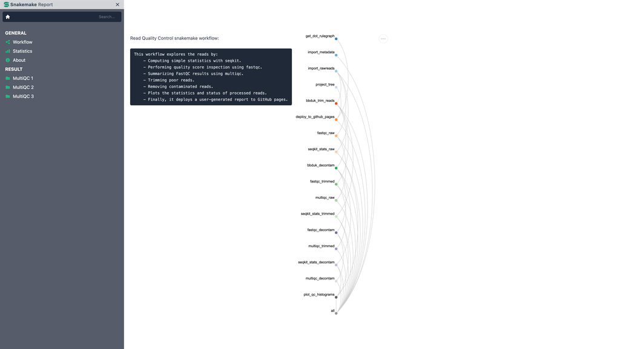

## Troubleshooting of FAQs

Last updated on April 11, 2023.  
Github_Repo: https://github.com/tmbuza/imap-read-quality-control.  
Repo compiled and maintained by: Teresia Mrema-Buza.